# Eluvio_DS_Challenge-Copy1

```python
# Importing Libraries

import numpy as np
import pandas as pd
import seaborn as sns
import matplotlib.pyplot as plt

import re
from sklearn.feature_extraction.text import CountVectorizer,TfidfVectorizer
from nltk.stem.porter import PorterStemmer
from sklearn.metrics import classification_report, confusion_matrix, accuracy_score
from nltk.tokenize import word_tokenize
from nltk.stem import WordNetLemmatizer
from sklearn.naive_bayes import MultinomialNB
from sklearn.svm import LinearSVC,SVC
from sklearn.metrics import accuracy_score
from sklearn.model_selection import train_test_split
from nltk.corpus import stopwords
import nltk
%matplotlib inline
```

```python
df_votes = pd.read_csv('D:\Chrome_Downloads\Eluvio_DS_Challenge.csv')
```

```python
df_votes.head()
```

|  | time_created | date_created | up_votes | down_votes | title | over_18 | author | category |
| --- | --- | --- | --- | --- | --- | --- | --- | --- |
| 0 | 1201232046 | 2008-01-25 | 3 | 0 | Scores killed in Pakistan clashes | False | polar | worldnews |
| 1 | 1201232075 | 2008-01-25 | 2 | 0 | Japan resumes refuelling mission | False | polar | worldnews |
| 2 | 1201232523 | 2008-01-25 | 3 | 0 | US presses Egypt on Gaza border | False | polar | worldnews |
| 3 | 1201233290 | 2008-01-25 | 1 | 0 | Jump-start economy: Give health care to all | False | fadi420 | worldnews |
| 4 | 1201274720 | 2008-01-25 | 4 | 0 | Council of Europe bashes EU&UN terror blacklist | False | mhermans | worldnews |

```python
 # Checking for NA's and Data Types

df_votes.info()
```

```
<class 'pandas.core.frame.DataFrame'>
RangeIndex: 509236 entries, 0 to 509235
Data columns (total 8 columns):
 #   Column        Non-Null Count   Dtype
---  ------        --------------   -----
 0   time_created  509236 non-null  int64
 1   date_created  509236 non-null  object
 2   up_votes      509236 non-null  int64
 3   down_votes    509236 non-null  int64
 4   title         509236 non-null  object
 5   over_18       509236 non-null  bool
 6   author        509236 non-null  object
 7   category      509236 non-null  object
dtypes: bool(1), int64(3), object(4)
memory usage: 27.7+ MB
```

```python
# Convert Date to Date format from object

df_votes['date_created'] = pd.to_datetime(df_votes['date_created'])
```

```python
# Length of the title

title = df_votes['title']
df_votes['len_title'] = [len(t) for t in title ]
```

```python
df_votes.nunique() # Checking values in each attribute
```

```
time_created    508329
date_created      3223
up_votes          5782
down_votes           1
title           500720
over_18              2
author           85838
category             1
len_title          311
dtype: int64
```

```python
df_votes['down_votes'].unique() # Down_vites column has all values as 0 single value
```

```
array([0], dtype=int64)
```

```python
df_votes['category'].unique() # Category column has values as worldnews
```

```
array(['worldnews'], dtype=object)
```

**Dropped both the columns with only 1 unique value.**

```python
df_votes.drop(['down_votes','category'],axis=1, inplace=True)
```

```python
df_votes.describe() # Summary Statistics for numerical columns
```

|  | time_created | up_votes | len_title |
| --- | --- | --- | --- |
| count | 5.092360e+05 | 509236.000000 | 509236.000000 |
| mean | 1.380240e+09 | 112.236283 | 89.446082 |
| std | 7.090436e+07 | 541.694675 | 59.701217 |
| min | 1.201232e+09 | 0.000000 | 1.000000 |
| 25% | 1.341585e+09 | 1.000000 | 52.000000 |
| 50% | 1.392909e+09 | 5.000000 | 66.000000 |
| 75% | 1.436527e+09 | 16.000000 | 100.000000 |
| max | 1.479817e+09 | 21253.000000 | 320.000000 |

up_votes column has minimum value of 0 and maximum value of 21253. 75% of up_votes are 16 and only remaining 25% fall in very high range. The distribution is highly right skewed or positive skewed where mean is larger than median.  
length of titles are also positively skewed with mean greater than median. only 25% of titles have lengths greater than 100 and these titles are having higher probability of getting high up_votes.

```python
df_votes.skew() # Skeweness of each column is checked
```

```
time_created    -0.744303
up_votes         8.107643
over_18         39.854391
len_title        1.695002
dtype: float64
```

**Skewness above 1 is highly skewed.**

```python
# Distribution of data for over_18 column
df_votes['over_18'].value_counts(normalize=True)
```

```
False    0.999372
True     0.000628
Name: over_18, dtype: float64
```

**99.93% of articles are for below_18 whereas only a handful of articles for over_18.**

```python
# Top 10 authors with their article titles based on up_votes

df_votes.sort_values('up_votes', ascending=False).head(30)
```

|  | time_created | date_created | up_votes | title | over_18 | author | len_title |
| --- | --- | --- | --- | --- | --- | --- | --- |
| 377200 | 1434818471 | 2015-06-20 | 21253 | A biotech startup has managed to 3-D print fak... | False | KRISHNA53 | 289 |
| 391415 | 1440421079 | 2015-08-24 | 13435 | Twitter has forced 30 websites that archive po... | False | joeyoungblood | 139 |
| 450818 | 1459706506 | 2016-04-03 | 13244 | 2.6 terabyte leak of Panamanian shell company ... | False | mister_geaux | 277 |
| 391318 | 1440367768 | 2015-08-23 | 12333 | The police officer who leaked the footage of t... | False | navysealassulter | 243 |
| 390252 | 1439939168 | 2015-08-18 | 11288 | Paris shooting survivor suing French media for... | False | seapiglet | 98 |
| 449809 | 1459336773 | 2016-03-30 | 11108 | Hundreds of thousands of leaked emails reveal ... | False | Xiroth | 100 |
| 397215 | 1442535288 | 2015-09-18 | 10922 | Brazil s Supreme Court has banned corporate co... | False | DoremusJessup | 92 |
| 390494 | 1440030633 | 2015-08-20 | 10515 | ISIS beheads 81-year-old pioneer archaeologist... | False | DawgsOnTopUGA | 188 |
| 500786 | 1476881235 | 2016-10-19 | 10394 | Feeding cows seaweed could slash global greenh... | False | mvea | 225 |
| 388230 | 1438963135 | 2015-08-07 | 10377 | Brazilian radio host famous for exposing corru... | False | fiffers | 122 |
| 465396 | 1464676302 | 2016-05-31 | 10289 | Every reference to the Great Barrier Reef remo... | False | Flamo_the_Idiot_Boy | 141 |
| 495329 | 1475072783 | 2016-09-28 | 10239 | Iceland s capital Reykjavik to switch off stre... | False | tiribazus | 122 |
| 447311 | 1458294452 | 2016-03-18 | 10161 | TTIP: secrecy around talks is profoundly unde... | False | Wagamaga | 129 |
| 187603 | 1370655122 | 2013-06-08 | 10159 | What we have... is... concrete proof of U.S.-... | False | dantesinfer | 261 |
| 389011 | 1439385059 | 2015-08-12 | 10086 | India sues Nestle for nearly $100m because lea... | False | damsteegt | 72 |
| 412603 | 1447448726 | 2015-11-13 | 9967 | Shootings reported in central Paris: Reports... | False | emr1028 | 90 |
| 354925 | 1426856986 | 2015-03-20 | 9954 | France decrees new rooftops must be covered in... | False | pnewell | 174 |
| 387922 | 1438857239 | 2015-08-06 | 9803 | iTunes is illegal under UK copyright law - The... | False | Noticemenot | 218 |
| 437930 | 1455204945 | 2016-02-11 | 9520 | Gravitational waves from black holes detected | False | Andromeda321 | 45 |
| 494404 | 1474731905 | 2016-09-24 | 9492 | The UN just declared antibiotic resistance “th... | False | MarcoshLA | 86 |
| 480475 | 1469724396 | 2016-07-28 | 9467 | Norway considers giving mountain to Finland as... | False | bimonscificon | 190 |
| 389068 | 1439403107 | 2015-08-12 | 9408 | Huge explosion reported in Chinese port city o... | False | haunted_cheesecake | 55 |
| 389806 | 1439756239 | 2015-08-16 | 9324 | GPS Trackers In Fake Elephant Tusks Reveal Ivo... | False | AmerikanInfidel | 64 |
| 446779 | 1458130384 | 2016-03-16 | 9319 | FIFA admits to World Cup hosting bribes, asks ... | False | jurvand | 70 |
| 489733 | 1473041714 | 2016-09-05 | 9316 | The giant panda is no longer an endangered spe... | False | madam1 | 247 |
| 326108 | 1417646102 | 2014-12-03 | 9303 | NASA officially announces Manned Mars Mission,... | False | Herman999999999 | 95 |
| 505849 | 1478593675 | 2016-11-08 | 9298 | NASA has completed the $8.7 billion James Webb... | False | Short_Term_Account | 299 |
| 358243 | 1428049229 | 2015-04-03 | 9232 | Six people who hid in a supermarket refrigerat... | False | DrSalted | 168 |
| 488435 | 1472574876 | 2016-08-30 | 9192 | Costa Rica celebrates 113 days of 100-percent ... | False | briancon | 77 |
| 455100 | 1461143885 | 2016-04-20 | 9011 | Pacific Bluefin Tuna: Population Drops 97% Due... | False | Vippero | 61 |

**Top 10 authors based on highest number of up_votes have written articles in 2nd half of 2015 and 2016 excluding a few which are in 1st half of the year. 2015 and 2016 have been years where the most voted articles are written.**  
**Top voted articles have higher count of number of words with an average of 175 chracters per title for the top 10.**

```python
# Bottom 10 authors with their article titles

df_votes.sort_values('up_votes', ascending=True).head(10)
```

|  | time_created | date_created | up_votes | title | over_18 | author | len_title |
| --- | --- | --- | --- | --- | --- | --- | --- |
| 170210 | 1364890028 | 2013-04-02 | 0 | U.S. moves sea-based radar to Western Pacific ... | False | readerseven | 71 |
| 69410 | 1292332988 | 2010-12-14 | 0 | Berlusconi Narrowly Survives Vote of Confidence | False | penguinbo | 47 |
| 393719 | 1441226296 | 2015-09-02 | 0 | Russian Military deal : India Approves $1.1 Bi... | False | bjpig | 99 |
| 69408 | 1292332108 | 2010-12-14 | 0 | Sepp Blatter says gays should refrain from sex... | False | TonyBLiar | 77 |
| 393720 | 1441226733 | 2015-09-02 | 0 | China to finally celebrate the end of World Wa... | False | completelyreal | 67 |
| 133758 | 1346159780 | 2012-08-28 | 0 | Myanmar president reshuffles cabinet: Major c... | False | davidreiss666 | 153 |
| 393730 | 1441229982 | 2015-09-02 | 0 | Schengen Agreement, why did we open EU borders... | False | InformedChoice | 137 |
| 69404 | 1292330630 | 2010-12-14 | 0 | Wikileaks Gossip Merely Annoying in Latin Am... | False | CoyoteLightning | 51 |
| 393737 | 1441231365 | 2015-09-02 | 0 | Two thirds of national security professionals ... | False | tayaravaknin | 132 |
| 247320 | 1390695893 | 2014-01-26 | 0 | UN Highlights North Korean rights violations | False | sachmo_muse | 44 |

```python
print('Average number of articles written by each author is', df_votes.groupby('author')['title'].count().mean())
```

```
Average number of articles written by each author is 5.932524056944477
```

```python
# Number of posts by top 20 authors

df_votes.groupby('author')['title'].count().sort_values(ascending=False).head(20)
```

```
author
davidreiss666         8897
anutensil             5730
DoremusJessup         5037
maxwellhill           4023
igeldard              4013
readerseven           3170
twolf1                2923
madam1                2658
nimobo                2564
madazzahatter         2503
ionised               2493
NinjaDiscoJesus       2448
bridgesfreezefirst    2405
SolInvictus           2181
Libertatea            2108
vigorous              2077
galt1776              1897
DougBolivar           1770
bob21doh              1698
trot-trot             1649
Name: title, dtype: int64
```

```python
# Average number of votes for top 20 authors

df_votes.groupby('author')['up_votes'].mean().sort_values(ascending=False).head(20)
```

```
author
navysealassulter       12333.0
seapiglet              11288.0
DawgsOnTopUGA          10515.0
Flamo_the_Idiot_Boy    10289.0
haunted_cheesecake      9408.0
bendertheoffender22     8781.0
crippledrejex           8601.0
FlandersNed             8446.0
lesseva96               8404.0
sverdrupian             8262.0
beachedazd              8260.0
NectarCollecting        8152.0
Bjartur                 8115.0
YoungPotato             8104.0
naybones                8031.0
house_of_kunt           8012.0
Grizzly-Slim            7899.0
lowbread                7869.0
Impmaster82             7836.0
Aerest                  7722.0
Name: up_votes, dtype: float64
```

```python
df_votes[df_votes['author'] == 'seapiglet']
```

|  | time_created | date_created | up_votes | title | over_18 | author | len_title |
| --- | --- | --- | --- | --- | --- | --- | --- |
| 390252 | 1439939168 | 2015-08-18 | 11288 | Paris shooting survivor suing French media for... | False | seapiglet | 98 |

```python
# Number of unique authors who write over_18 articles

df_votes['author'][df_votes['over_18'] == True].nunique()
```

```
285
```

```python
# Authors who have written over_18 articles

df_votes['author'][df_votes['over_18'] == True].unique()
```

[output not shown]

[output cut: 13 more lines]

[output not shown]

```python
# Number of unique authors who write below_18 articles

len(df_votes['author'][df_votes['over_18'] == False].unique())
```

```
85754
```

```python
# Date of 1st article and last article

print('Date of the 1st article is', df_votes['date_created'].min())

print('Date of the last article is', df_votes['date_created'].max())
```

```
Date of the 1st article is 2008-01-25 00:00:00
Date of the last article is 2016-11-22 00:00:00
```

Article titles are for alomost 9 years. Titles around some major events could be used to get more detailed patterns. One of the examples would be 2016 US Presential Election during which the articles would be more related to the candidates and parties along with their promises, adgenda and probable winner.

```python
# Number of days difference between the 1st and last article based on date

print('Date difference between the oldest and the latest article is', df_votes['date_created'].max() - df_votes['date_created'].min())
```

```
Date difference between the oldest and the latest article is 3224 days 00:00:00
```

## Word Cloud showing the most frequently occuring words in the titles

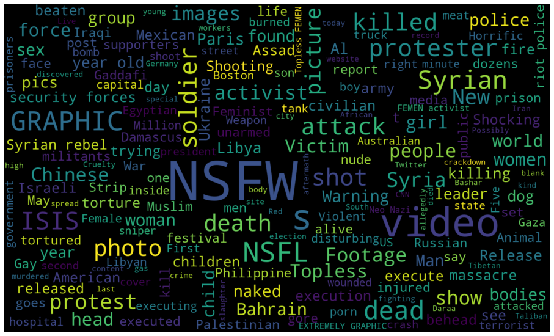

```python
# Word cloud for titles which are over_18 = True

textData = []
for t in df_votes.title[df_votes['over_18'] == True]:
    textData.append(t)
textData = pd.Series(textData).str.cat(sep=' ')

from wordcloud import WordCloud
wordcloud = WordCloud(width=2000, height=1200,max_font_size=200).generate(textData)
plt.figure(figsize=(16,12))
plt.imshow(wordcloud, interpolation="bilinear")
plt.axis("off")
plt.show()
```

**The words which occure the most in the titles where over_18 is True is related to fight and war like massacre, death, ISIS, dead, killed, shoot, soldier, attack along with sex terms such as nude, Topless, naked, strip. People living in different countries are mentioned such as Syrian, Russian, Chinese, American along with country names. The articles over_18 seem to be for the audience which need to be above 18.**

[figure not shown]

```python
# Word cloud for titles which are over_18 = False

textData = []
for t in df_votes.title[df_votes['over_18'] == False]:
    textData.append(t)
textData = pd.Series(textData).str.cat(sep=' ')

from wordcloud import WordCloud
wordcloud = WordCloud(width=2000, height=1200,max_font_size=200).generate(textData)
plt.figure(figsize=(16,12))
plt.imshow(wordcloud, interpolation="bilinear")
plt.axis("off")
plt.show()
```

**Country names are most bold meaning they occur the most number of times such as Russia, UK, India, North Korea, Pakistan, Iraq, Israel. Protest, killed, death, BBC occur with high frequency but there are hardly any words not suitable for children below 18.**

## Exploratory Analysis

```python
# Function to get top N words from the title

from sklearn.feature_extraction.text import CountVectorizer


def get_top_n_words(corpus, n=None,stopword=None,nrange=(1,1)):
    vec = CountVectorizer(stop_words=stopword,ngram_range=nrange).fit(corpus)
    bag_of_words = vec.transform(corpus)
    sum_words = bag_of_words.sum(axis=0)
    words_freq = [(word, sum_words[0, idx]) for word, idx in vec.vocabulary_.items()]
    words_freq =sorted(words_freq, key = lambda x: x[1], reverse=True)
    return words_freq[:n]
```

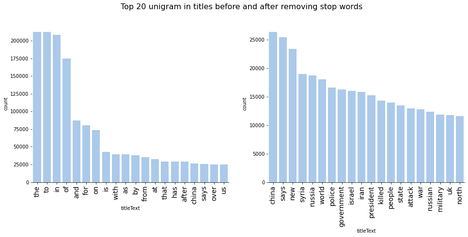

```python
# Top 20 most common unigrams occuring in all the titles

common_words_withStopwords = get_top_n_words(df_votes['title'], 20)
common_words_withoutStopwords = get_top_n_words(df_votes['title'], 20,'english')

df1 = pd.DataFrame(common_words_withStopwords, columns = ['titleText' , 'count'])
df2 = pd.DataFrame(common_words_withoutStopwords, columns = ['titleText' , 'count'])

f, ax = plt.subplots(1,2,figsize=(16, 6))
sns.set_color_codes("pastel")
g = sns.barplot(x="titleText", y="count", data=df1, color="b",ax=ax[0])
t = sns.barplot(x="titleText", y="count", data=df2, color="b",ax=ax[1])
g.set_xticklabels(rotation=90,labels=df1['titleText'],fontsize =14)
t.set_xticklabels(rotation=90,labels=df2['titleText'],fontsize =14)
sns.despine(left = True)
plt.suptitle("Top 20 unigram in titles before and after removing stop words",fontsize=16);
```

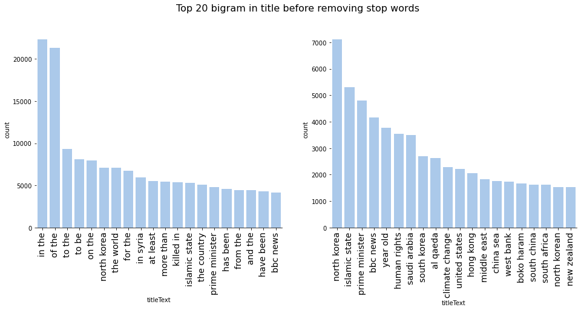

```python
# Top 20 Bigrams occuring in all the titles

common_words_withStopwords = get_top_n_words(df_votes['title'], 20,None,(2,2))
common_words_withoutStopwords = get_top_n_words(df_votes['title'], 20,'english',(2,2))

df1 = pd.DataFrame(common_words_withStopwords, columns = ['titleText' , 'count'])
df2 = pd.DataFrame(common_words_withoutStopwords, columns = ['titleText' , 'count'])

f, ax = plt.subplots(1,2,figsize=(16, 6))
sns.set_color_codes("pastel")
g=sns.barplot(x="titleText", y="count", data=df1, color="b",ax=ax[0])
t=sns.barplot(x="titleText", y="count", data=df2, color="b",ax=ax[1])
g.set_xticklabels(rotation=90,labels=df1['titleText'],fontsize =14)
t.set_xticklabels(rotation=90,labels=df2['titleText'],fontsize =14)
sns.despine(left = True)
plt.suptitle("Top 20 bigram in title before removing stop words",fontsize=16);
```

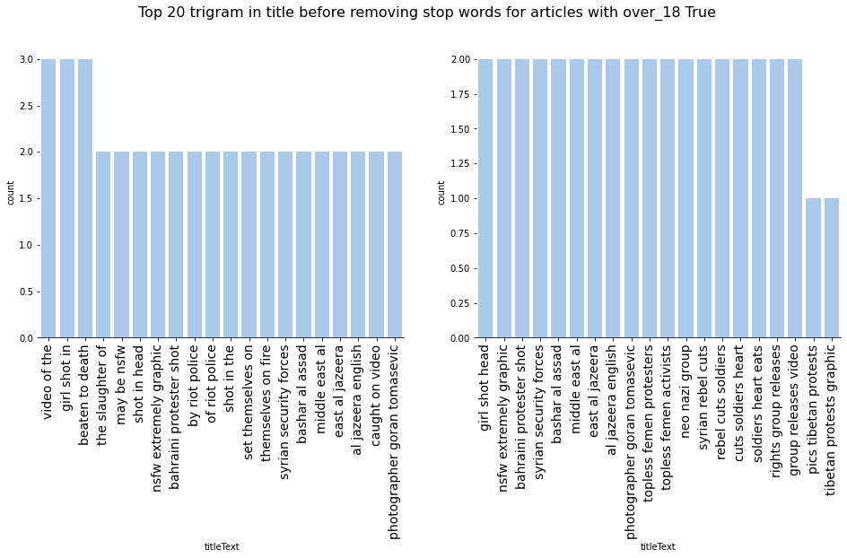

```python
# Top 20 Trigrams occuring in the article titles where over_18 is True

common_words_withStopwords = get_top_n_words(df_votes.title[df_votes['over_18'] == True], 20,None,(3,3))
common_words_withoutStopwords = get_top_n_words(df_votes.title[df_votes['over_18'] == True], 20,'english',(3,3))

df1 = pd.DataFrame(common_words_withStopwords, columns = ['titleText' , 'count'])
df2 = pd.DataFrame(common_words_withoutStopwords, columns = ['titleText' , 'count'])

f, ax = plt.subplots(1,2,figsize=(16, 6))
sns.set_color_codes("pastel")
g=sns.barplot(x="titleText", y="count", data=df1, color="b",ax=ax[0])
t=sns.barplot(x="titleText", y="count", data=df2, color="b",ax=ax[1])
g.set_xticklabels(rotation=90,labels=df1['titleText'],fontsize =14)
t.set_xticklabels(rotation=90,labels=df2['titleText'],fontsize =14)
sns.despine(left = True)
plt.suptitle("Top 20 trigram in title before removing stop words for articles with over_18 True",fontsize=16);
```

**It can be seen that trigrams in over_18 True contain some words not suitable for audience below 18 such as topless femem activists, protestors, extremely graphic etc. whereas for bigrams the words are related to countries and other issues such as climate change, human rights. Unigrams do not make sense as they are words like world, russia, china, says.**

# Topic Modeling

```python
import nltk
nltk.download('stopwords')
```

```
True
```

```python
# NLTK English Stop words

from nltk.corpus import stopwords
stop_words = stopwords.words('english')
```

```python
# Count vectorizer with bigrams

gram22_count_vectorizer = CountVectorizer(encoding='latin-1', min_df=2,ngram_range=(2,2),stop_words='english')
```

```python
# Countvectorizer with trigrams

gram33_count_vectorizer = CountVectorizer(encoding='latin-1',min_df=2, ngram_range=(3,3),stop_words='english')
```

```python
# TFIDF bigrams vectorizer

ngram_tfidf_vectorizer = TfidfVectorizer(encoding='latin-1', use_idf=True,ngram_range=(2,2) ,min_df=2,stop_words='english')
```

```python
# Vectorizing the titles using count vectorizer and bigrams to get document term matrix

doc_mat = gram22_count_vectorizer.fit_transform(df_votes['title'].values.astype('U'))
```

```python
# Vectorizing the titles using count vectorizer and trigrams to get document term matrix

doc_mat_3 = gram33_count_vectorizer.fit_transform(df_votes['title'].values.astype('U'))
```

```python
# Vectorizing the titles using TFIDF vectorizer and bigrams to get document term matrix

doc_mat_tfidf = ngram_tfidf_vectorizer.fit_transform(df_votes['title'].values.astype('U'))
```

```python
# Document term matrix

doc_mat
```

```
<509236x515023 sparse matrix of type '<class 'numpy.int64'>'
	with 2670077 stored elements in Compressed Sparse Row format>
```

```python
# LDA algorithm from sklearn is used to perform topic modeling with 20 topics

from sklearn.decomposition import LatentDirichletAllocation

LDA = LatentDirichletAllocation(n_components=20, random_state=42)
LDA.fit(doc_mat)
```

```
LatentDirichletAllocation(n_components=20, random_state=42)
```

```python
# Generating the top 10 keywords for each topic to identity the topic

for i,topic in enumerate(LDA.components_):
    print(f'Top 10 words for topic #{i}:')
    print([gram22_count_vectorizer.get_feature_names()[i] for i in topic.argsort()[-10:]])
    print('\n')
```

```
Top 10 words for topic #0:
['abc news', 'sexual abuse', 'united arab', 'arab emirates', 'pope francis', 'bbc news', 'prime minister', 'hugo chavez', 'climate change', 'tear gas']


Top 10 words for topic #1:
['world powers', 'nuclear program', 'pussy riot', 'foreign minister', 'nuclear talks', 'prime minister', 'far right', 'nuclear deal', 'iran nuclear', 'bbc news']


Top 10 words for topic #2:
['turkey erdogan', 'nobel prize', 'papua new', 'new guinea', 'middle east', 'islamic state', 'president barack', 'jazeera english', 'barack obama', 'al jazeera']


Top 10 words for topic #3:
['trans pacific', 'prime minister', 'state john', 'israel news', 'peace talks', 'israeli troops', 'secretary state', 'john kerry', 'south korea', 'west bank']


Top 10 words for topic #4:
['airlines flight', 'saudi arabia', 'sanctions russia', 'bbc news', 'suicide bomber', 'south sudan', 'malaysia airlines', 'african republic', 'central african', 'chemical weapons']


Top 10 words for topic #5:
['bbc news', 'secretary general', 'kim jong', 'world health', 'ban ki', 'ki moon', 'supreme leader', 'world news', 'south korea', 'north korea']


Top 10 words for topic #6:
['south korea', 'child sex', 'south africa', 'sex abuse', 'west bank', 'police arrest', 'islamic state', 'year old', 'boko haram', 'north korea']


Top 10 words for topic #7:
['west africa', 'aircraft carrier', 'shot dead', 'civil war', 'climate change', 'sierra leone', 'julian assange', 'global warming', 'south china', 'china sea']


Top 10 words for topic #8:
['earthquake strikes', 'south africa', 'record high', 'peace talks', 'earthquake hits', 'islamic state', 'united states', 'osama bin', 'magnitude earthquake', 'bin laden']


Top 10 words for topic #9:
['anti gay', 'paris attacks', 'new zealand', 'foreign minister', 'high speed', 'tel aviv', 'nytimes com', 'syrian army', 'edward snowden', 'islamic state']


```

[output cut: 23 more lines]

```

Top 10 words for topic #16:
['bo xilai', 'ai weiwei', 'south africa', 'cyber attack', 'unity government', 'plane crash', 'peace talks', 'fighter jet', 'islamic state', 'saudi arabia']


Top 10 words for topic #17:
['000 year', 'drone strikes', 'old boy', 'bird flu', 'tony abbott', 'anti government', 'suu kyi', 'new zealand', 'prime minister', 'year old']


Top 10 words for topic #18:
['al qaida', 'zika virus', 'pope francis', 'fukushima nuclear', 'south sudan', 'power plant', 'nuclear plant', 'islamic state', 'nuclear power', 'al qaeda']


Top 10 words for topic #19:
['united states', 'hunger strike', 'islamic state', 'refugee camp', 'south korean', 'nelson mandela', 'nuclear test', 'syrian rebels', 'south korea', 'north korea']
```

```python
# LDA algorithm from sklearn is used to perform topic modeling with 30 topics

from sklearn.decomposition import LatentDirichletAllocation

LDA = LatentDirichletAllocation(n_components=30, random_state=42)
LDA.fit(doc_mat)
```

```
LatentDirichletAllocation(n_components=30, random_state=42)
```

```python
# Generating top 10 words for each topic with highest probability where number of topics is 30

for i,topic in enumerate(LDA.components_):
    print(f'Top 10 words for topic #{i}:')
    print([gram22_count_vectorizer.get_feature_names()[i] for i in topic.argsort()[-10:]])
    print('\n')
```

```
Top 10 words for topic #0:
['abc news', 'bbc news', 'child abuse', 'united arab', 'arab emirates', 'sexual abuse', 'hugo chavez', 'jazeera english', 'climate change', 'al jazeera']


Top 10 words for topic #1:
['oil prices', 'nuclear program', 'bomber kills', 'east jerusalem', 'prime minister', 'suicide bomber', 'iran nuclear', 'nuclear deal', 'david cameron', 'bbc news']


Top 10 words for topic #2:
['social media', 'genital mutilation', 'sri lanka', 'islamic state', 'turkey erdogan', 'papua new', 'new guinea', 'president barack', 'nobel prize', 'barack obama']


Top 10 words for topic #3:
['japan pm', 'free trade', 'ukrainian president', 'terror threat', 'defense ministry', 'pacific partnership', 'trans pacific', 'west bank', 'israel news', 'south korea']


Top 10 words for topic #4:
['panama papers', 'bbc news', 'syria chemical', 'saudi arabia', 'sanctions russia', 'red cross', 'south sudan', 'chemical weapons', 'african republic', 'central african']


Top 10 words for topic #5:
['hong kong', 'bbc news', 'saudi arabia', 'iran supreme', 'health organization', 'north korea', 'world health', 'supreme leader', 'international criminal', 'criminal court']


Top 10 words for topic #6:
['nuclear test', 'korea nuclear', 'islamic state', 'south korean', 'korea says', 'north korean', 'south korea', 'south china', 'china sea', 'north korea']


Top 10 words for topic #7:
['prime minister', 'aircraft carrier', 'german chancellor', 'chancellor angela', 'shinzo abe', 'global warming', 'sierra leone', 'civil war', 'angela merkel', 'julian assange']


Top 10 words for topic #8:
['hong kong', 'bin laden', 'earthquake hits', 'united states', 'australian pm', 'sanctions iran', 'islamic state', 'world heritage', 'record high', 'peace talks']


Top 10 words for topic #9:
['costa rica', 'nytimes com', 'tel aviv', 'islamic state', 'syrian army', 'osama bin', 'anti gay', 'anti government', 'edward snowden', 'bin laden']


```

[output cut: 63 more lines]

```

Top 10 words for topic #26:
['bbc news', 'rights group', 'rights activist', 'strike kills', 'rights groups', 'rights abuses', 'united nations', 'saudi arabia', 'rights watch', 'human rights']


Top 10 words for topic #27:
['israeli soldiers', 'used chemical', 'islamic state', 'long range', 'syria war', 'attack kills', 'suicide attack', 'bird flu', 'syrian rebels', 'chemical weapons']


Top 10 words for topic #28:
['paris climate', 'south african', 'greenhouse gas', 'flight mh370', 'climate change', 'airlines flight', 'space station', 'malaysia airlines', 'new zealand', 'south africa']


Top 10 words for topic #29:
['leader kim', 'korean leader', 'aung san', 'san suu', 'jong il', 'suu kyi', 'tear gas', 'plane crash', 'north korean', 'kim jong']
```

```python
# Using LDA to get key words for each title based on LDA

topic_values = LDA.transform(doc_mat)
topic_values.shape
```

```
(509236, 30)
```

```python
# Generating the topic for each title based on the highest probability of words occuring in the title

df_votes['Topic'] = topic_values.argmax(axis=1)
```

```python
df_votes.head()
```

|  | time_created | date_created | up_votes | title | over_18 | author | len_title | Topic |
| --- | --- | --- | --- | --- | --- | --- | --- | --- |
| 0 | 1201232046 | 2008-01-25 | 3 | Scores killed in Pakistan clashes | False | polar | 33 | 15 |
| 1 | 1201232075 | 2008-01-25 | 2 | Japan resumes refuelling mission | False | polar | 32 | 6 |
| 2 | 1201232523 | 2008-01-25 | 3 | US presses Egypt on Gaza border | False | polar | 31 | 23 |
| 3 | 1201233290 | 2008-01-25 | 1 | Jump-start economy: Give health care to all | False | fadi420 | 44 | 26 |
| 4 | 1201274720 | 2008-01-25 | 4 | Council of Europe bashes EU&UN terror blacklist | False | mhermans | 47 | 7 |

```python
# LDA to generate 20 topics for trigram count vectorized titles

from sklearn.decomposition import LatentDirichletAllocation

LDA = LatentDirichletAllocation(n_components=20, random_state=42)
LDA.fit(doc_mat_3)
```

```
LatentDirichletAllocation(n_components=20, random_state=42)
```

```python
# 20 topics for trigrams with count vectorizer with top 10 most important words for each topic

for i,topic in enumerate(LDA.components_):
    print(f'Top 10 words for topic #{i}:')
    print([gram33_count_vectorizer.get_feature_names()[i] for i in topic.argsort()[-10:]])
    print('\n')
```

```
Top 10 words for topic #0:
['jean claude juncker', 'new world order', 'al qaeda militants', 'malaysia airlines plane', 'missing malaysia airlines', 'australian prime minister', 'prime minister benjamin', 'minister benjamin netanyahu', 'north korea threatens', 'israeli prime minister']


Top 10 words for topic #1:
['nigeria boko haram', 'korea nuclear test', 'wikileaks founder julian', 'human rights activist', 'founder julian assange', 'saudi led coalition', 'european court human', 'court human rights', 'north korea nuclear', 'iran nuclear deal']


Top 10 words for topic #2:
['summary evenings stories', 'uk links associated', 'quick summary evenings', 'trans pacific partnership', 'russian foreign minister', 'use chemical weapons', 'president hugo chavez', 'international space station', 'anti government protests', 'al qaeda linked']


Top 10 words for topic #3:
['south african president', 'syrian chemical weapons', 'police tear gas', 'korean leader kim', 'islamic state iraq', 'recep tayyip erdogan', 'leader kim jong', 'north korean leader', 'great barrier reef', 'new york times']


Top 10 words for topic #4:
['greenhouse gas emissions', 'north korea missile', 'al jazeera journalists', 'president mahmoud ahmadinejad', 'suicide bomber kills', 'east china sea', 'human rights groups', 'death toll rises', 'world war ii', 'central african republic']


Top 10 words for topic #5:
['japan south korea', 'uk prime minister', 'british prime minister', '14 year old', 'prime minister david', 'minister david cameron', 'kim jong il', 'child sex abuse', 'year old girl', 'nuclear power plant']


Top 10 words for topic #6:
['chinese president xi', 'ayatollah ali khamenei', 'pirate bay founder', 'president hosni mubarak', 'magnitude earthquake hits', 'president xi jinping', 'iran supreme leader', 'syria chemical weapons', 'san suu kyi', 'aung san suu']


Top 10 words for topic #7:
['news australian broadcasting', 'west bank settlements', 'australian broadcasting corporation', 'japanese prime minister', 'new prime minister', 'declares state emergency', 'minister shinzo abe', 'prime minister shinzo', 'united arab emirates', 'osama bin laden']


Top 10 words for topic #8:
['rights group says', 'islamic state claims', 'new year eve', 'president rodrigo duterte', 'human rights group', 'minister tony abbott', 'middle east al', 'east al jazeera', 'prime minister tony', 'al jazeera english']


Top 10 words for topic #9:
['russian prime minister', 'million year old', 'news guardian uk', 'bbc news syria', 'islamic state fighters', 'killed drone strike', 'president hamid karzai', 'al qaeda leader', 'world news guardian', 'al jazeera english']


```

[output cut: 23 more lines]

```

Top 10 words for topic #16:
['air force base', 'issues arrest warrant', 'free trade agreement', 'join islamic state', 'dominique strauss kahn', 'sub saharan africa', 'boko haram attack', 'led air strikes', 'boko haram militants', 'russian foreign ministry']


Top 10 words for topic #17:
['chemical weapons attack', 'syrian civil war', 'free syrian army', 'anti gay law', 'president francois hollande', 'human rights violations', 'human rights council', 'syria civil war', 'world health organization', 'human rights watch']


Top 10 words for topic #18:
['korea kim jong', '10 year old', '12 year old', 'north korea kim', 'year old girl', 'anti government protesters', '13 year old', 'human rights abuses', 'year old boy', 'ban ki moon']


Top 10 words for topic #19:
['airlines flight mh370', 'syrian electronic army', 'anti gay laws', 'nuclear power plants', 'disputed south china', 'bakr al baghdadi', 'abu bakr al', 'china sea dispute', 'female genital mutilation', 'south china sea']
```

For Trigrams, the topics could be classified into categories such as Human rights, Child sex abuse, Syria civil war, paris terror attacks, nuclear power plant, climate change, malaysian plane crash, emergency declaration, earthquake etc.  
Topic Modeling helped to see the summary of topics on which articles would have be wrritten based just on their titles.

```python
# Generating 20 topics to summarize the titles based on Bigram to Trigrams for TFIDF Vectorizer

from sklearn.decomposition import LatentDirichletAllocation

LDA = LatentDirichletAllocation(n_components=20, random_state=42)
LDA.fit(doc_mat_tfidf)
```

```
LatentDirichletAllocation(n_components=20, random_state=42)
```

```python
# Topics with words generated for each of the 20 topics for tfidf

for i,topic in enumerate(LDA.components_):
    print(f'Top 10 words for topic #{i}:')
    print([ngram_tfidf_vectorizer.get_feature_names()[i] for i in topic.argsort()[-10:]])
    print('\n')
```

```
Top 10 words for topic #0:
['human rights', 'islamic state', 'south korea', 'china sea', 'prime minister', 'bbc news', 'climate change', 'hugo chavez', 'north korea', 'earthquake hits']


Top 10 words for topic #1:
['iran nuclear', 'saudi arabia', 'nuclear deal', 'foreign minister', 'far right', 'golden dawn', 'islamic state', 'north korea', 'prime minister', 'bbc news']


Top 10 words for topic #2:
['john kerry', 'middle east', 'prime minister', 'nobel prize', 'barack obama', 'north korea', 'islamic state', 'pirate bay', 'jazeera english', 'al jazeera']


Top 10 words for topic #3:
['female genital', 'north korea', 'boko haram', 'genital mutilation', 'pacific partnership', 'saudi arabia', 'bbc news', 'trans pacific', 'human rights', 'south korea']


Top 10 words for topic #4:
['islamic state', 'missing malaysia', 'flight mh370', 'saudi arabia', 'bbc news', 'suicide bomber', 'airlines flight', 'syria chemical', 'chemical weapons', 'malaysia airlines']


Top 10 words for topic #5:
['suicide bombers', 'secretary general', 'year old', 'south korea', 'bbc news', 'iran supreme', 'supreme leader', 'ban ki', 'ki moon', 'north korea']


Top 10 words for topic #6:
['bbc news', 'korea nuclear', 'china sea', 'south china', 'south africa', 'islamic state', 'year old', 'boko haram', 'west bank', 'north korea']


Top 10 words for topic #7:
['human rights', 'islamic state', 'south china', 'climate change', 'julian assange', 'china sea', 'bbc news', 'global warming', 'north korea', 'sierra leone']


Top 10 words for topic #8:
['sanctions iran', 'prime minister', 'saudi arabia', 'bbc news', 'osama bin', 'new sanctions', 'united states', 'islamic state', 'north korea', 'bin laden']


Top 10 words for topic #9:
['costa rica', 'china bans', 'earthquake strikes', 'nytimes com', 'edward snowden', 'magnitude earthquake', 'human rights', 'islamic state', 'central african', 'african republic']


```

[output cut: 23 more lines]

```

Top 10 words for topic #16:
['south africa', 'ai weiwei', 'north korea', 'plane crash', 'queen elizabeth', 'al qaeda', 'prime minister', 'year old', 'islamic state', 'saudi arabia']


Top 10 words for topic #17:
['saudi arabia', 'south korea', 'islamic state', 'bird flu', 'new zealand', 'aung san', 'san suu', 'prime minister', 'year old', 'suu kyi']


Top 10 words for topic #18:
['saudi arabia', 'prime minister', 'year old', 'south sudan', 'north korea', 'death toll', 'bbc news', 'pope francis', 'islamic state', 'al qaeda']


Top 10 words for topic #19:
['short range', 'saudi arabia', 'syrian rebels', 'rupert murdoch', 'hong kong', 'south korea', 'nelson mandela', 'bbc news', 'islamic state', 'north korea']
```

Bigrams are most suitable for topic modeling to generate the topics which summarize the titles better.  
The Number of topics have been tested for 20 and 30 but both of them have some discrepancies which would be solved by domain knowledge about the articles. Consulting with domain experts in the field to get a clear idea about how many number of topics to be used for topic modeling would increase the efficiency. Some common stop words for articles can also be used to avoid getting words which are not important based on domain knowledge.  
Gensim for Topic Modeling has some advanced features which were not tried along with using SpaCy library instead of NLTK could result in better results.

# Machine Learning Models

**Predicting up_votes as a whole number is a Regression problem with more than 1000 values. Also, as more than 75% of up_votes are less than 100, this problem can be converted to binary classification problem with titles having more than 100 up_votes considered as 1 target category whereas all the other titles with < 100 votes as another category.**

```python
# Converting up_votes to binary for making it classification problem

df_votes['rating'] = [1 if i > 100 else 0 for i in df_votes['up_votes']]
```

```python
# Splitting the data into train and test with 80:20 ratio

X_train, X_test, y_train, y_test = train_test_split(df_votes['title'].values, df_votes['rating'].values, test_size=0.2, random_state=0)

print(X_train.shape, y_train.shape, X_test.shape, y_test.shape)
print(X_train[0])
print(y_train[0])
print(X_test[0])
print(y_test[0])
```

```
(407388,) (407388,) (101848,) (101848,)
Fijian newspapers are turning into the Onion
0
Israeli Leaders Decry Geneva Accord
0
```

## Multinomial Naive Bayes

```python
# Initialize the MNB and fit the train data using Bigram TFIDF vectorizer

clf = MultinomialNB()
clf.fit(ngram_tfidf_vectorizer.fit_transform(X_train), y_train)
```

```
MultinomialNB()
```

```python
# Transform the test data and not fit as it would cause data leaking

X_test_vec = ngram_tfidf_vectorizer.transform(X_test)
```

```python
# Calculating the score on test data

clf.score(X_test_vec,y_test)
```

```
0.901647553216558
```

```python
# Prediction the test data

y_predict = clf.predict(X_test_vec)
```

```python
print(classification_report(y_test, y_predict))
```

```
              precision    recall  f1-score   support

           0       0.90      1.00      0.95     91835
           1       0.30      0.00      0.00     10013

    accuracy                           0.90    101848
   macro avg       0.60      0.50      0.47    101848
weighted avg       0.84      0.90      0.86    101848
```

```python
# Most informative features for a class
def show_most_and_least_informative_features(vectorizer, clf, class_idx=0, n=10):
    feature_names = vectorizer.get_feature_names()
    coefs_with_fns = sorted(zip(clf.coef_[class_idx], feature_names))
    top = zip(coefs_with_fns[:n], coefs_with_fns[-n:])
    for (coef_1, fn_1), (coef_2, fn_2) in top:
        print("\t%.4f\t%-15s\t\t%.4f\t%-15s" % (coef_1, fn_1, coef_2, fn_2))
```

```python
# show most positive features for a class
show_most_and_least_informative_features(ngram_tfidf_vectorizer, clf, class_idx=0, n=40)
```

```
	-13.1257	00 bst         		-9.9463	000 year
	-13.1257	00 kyiv        		-9.9279	court rules
	-13.1257	00 local       		-9.8835	tens thousands
	-13.1257	00 pm          		-9.8820	syrian rebels
	-13.1257	00 usd         		-9.8715	old girl
	-13.1257	000 12         		-9.8408	united nations
	-13.1257	000 13         		-9.8118	european union
	-13.1257	000 14         		-9.7902	west bank
	-13.1257	000 15         		-9.7827	years ago
	-13.1257	000 1990s      		-9.7489	boko haram
	-13.1257	000 20         		-9.7439	al jazeera
	-13.1257	000 2004       		-9.7364	000 people
	-13.1257	000 2015       		-9.7311	supreme court
	-13.1257	000 2017       		-9.6984	south africa
	-13.1257	000 2018       		-9.6972	10 000
	-13.1257	000 800        		-9.6908	middle east
	-13.1257	000 85         		-9.6819	world largest
	-13.1257	000 900        		-9.6498	shot dead
	-13.1257	000 abort      		-9.6345	pirate bay
	-13.1257	000 accused    		-9.6021	david cameron
	-13.1257	000 activist   		-9.5748	al qaeda
	-13.1257	000 adrift     		-9.4936	world cup
	-13.1257	000 adults     		-9.4716	julian assange
	-13.1257	000 afghans    		-9.3555	hong kong
	-13.1257	000 ak         		-9.3449	kim jong
	-13.1257	000 al         		-9.3340	vladimir putin
	-13.1257	000 alleged    		-9.3203	north korean
	-13.1257	000 americans  		-9.2589	pope francis
	-13.1257	000 amid       		-9.2128	bbc news
	-13.1257	000 applicants 		-9.1644	south korea
	-13.1257	000 applications		-9.1628	new zealand
	-13.1257	000 applied    		-9.0781	edward snowden
	-13.1257	000 armenians  		-9.0339	climate change
	-13.1257	000 arrests    		-9.0287	united states
	-13.1257	000 arrivals   		-8.8139	human rights
	-13.1257	000 artworks   		-8.7018	prime minister
	-13.1257	000 assyrians  		-8.5951	islamic state
	-13.1257	000 attend     		-8.5427	saudi arabia
	-13.1257	000 australian 		-8.2517	year old
	-13.1257	000 average    		-8.1340	north korea
```

Top words which contribute to the Multinomial NB model prediction are listed above.

```python
# MNB using Bigram Count Vectorizer

clf_count = MultinomialNB()
clf_count.fit(gram22_count_vectorizer.fit_transform(X_train), y_train)
```

```
MultinomialNB()
```

```python
X_test_vec_count = gram22_count_vectorizer.transform(X_test)
```

```python
clf_count.score(X_test_vec_count,y_test)
```

```
0.8928599481580395
```

```python
y_predict_count = clf_count.predict(X_test_vec_count)
```

```python
print(classification_report(y_test, y_predict_count))
```

```
              precision    recall  f1-score   support

           0       0.91      0.98      0.94     91835
           1       0.27      0.05      0.09     10013

    accuracy                           0.89    101848
   macro avg       0.59      0.52      0.52    101848
weighted avg       0.84      0.89      0.86    101848
```

Count Vectorizer gives better result for up_votes = 1 ( 1 for votes > 100) as compared to TFIDF Vectorizer.  
The data is highly skewed and there are only a handful of samples for votes =1 which why the MNB is not able to predict this class properly.  
Numbers are always catchy when they are part of article titles but the ML models seem to be not benefitting from these. Taking out numbers from the titles can improve the model prediction.

## Linear SVM

```python
svm_clf = LinearSVC(C=1.5)

# use the training data to train the model with TFIDF Vectorizer

svm_clf.fit(ngram_tfidf_vectorizer.fit_transform(X_train),y_train)
```

```
LinearSVC(C=1.5)
```

```python
svm_clf.score(X_test_vec,y_test)
```

```
0.8801645589505931
```

```python
print(classification_report(y_test, svm_clf.predict(X_test_vec)))
```

```
              precision    recall  f1-score   support

           0       0.91      0.97      0.94     91835
           1       0.19      0.07      0.10     10013

    accuracy                           0.88    101848
   macro avg       0.55      0.52      0.52    101848
weighted avg       0.84      0.88      0.85    101848
```

```python
# use the training data to train the model with count vectorizer

svm_clf.fit(gram22_count_vectorizer.fit_transform(X_train),y_train)
```

```
LinearSVC(C=1.5)
```

```python
svm_clf.score(X_test_vec_count,y_test)
```

```
0.8637872123163931
```

```python
print(classification_report(y_test, svm_clf.predict(X_test_vec_count)))
```

```
              precision    recall  f1-score   support

           0       0.91      0.95      0.93     91835
           1       0.19      0.11      0.14     10013

    accuracy                           0.86    101848
   macro avg       0.55      0.53      0.53    101848
weighted avg       0.84      0.86      0.85    101848
```

```python
# Words or features based on count vectorizer to predict the votes

feature_ranks = sorted(zip(svm_clf.coef_[0], gram22_count_vectorizer.get_feature_names()))
```

```python
# One vs One classifier to get keywords helping the SVC model for predicting up_votes = 1
# Up_votes 1 vs Up_votes not 1 for the classifier

votes_category_10 = feature_ranks[-20:]
print("votes category words")
for i in range(0, len(votes_category_10)):
    print(votes_category_10[i])
print()
```

```
votes category words
(1.8179892612718065, 'schools time')
(1.8194707529758836, 'opens hearings')
(1.8203284116054361, 'superior court')
(1.8214956835541063, 'criticised creating')
(1.8230603617975818, 'world likely')
(1.8301411761108146, 'radical imam')
(1.8358515134019053, 'minister start')
(1.845101391261542, 'obama withdrawing')
(1.8453199008399241, 'acta ratification')
(1.8497078714171498, 'china running')
(1.8570506636112518, 'canadians protesting')
(1.8635769966902902, 'material world')
(1.9148066617482336, 'israel bulldozes')
(1.9173725671048263, 'probe philae')
(1.9227194294837004, 'species ancient')
(1.924842657584175, 'isis sharia')
(2.0406239261222194, 'story nsa')
(2.0854062932708164, 'gmail users')
(2.099795808883644, 'nazis new')
(2.350053410732635, 'child massacre')
```

```python
# One vs One Classifier strategy for Linear SVC to see the words which do not contribute to the model prediction least useful words

not_votes_category_10 = feature_ranks[:20]
print("votes category words")
for i in range(0, len(not_votes_category_10)):
    print(not_votes_category_10[i])
print()
```

```
votes category words
(-2.0380905111122916, '12 relatives')
(-1.9050046369227402, 'elderly committing')
(-1.7106057995164632, 'says seoul')
(-1.6796447682932858, 'mafia state')
(-1.6491406129747896, 'uk formally')
(-1.6312339269824212, 'web creator')
(-1.5682769101874676, 'hunting tiger')
(-1.5500900793442314, 'moon called')
(-1.5351907468852106, 'ford powers')
(-1.5328741172255214, 'reactor construction')
(-1.5323337057402513, 'filled condoms')
(-1.5319426012342008, 'exports gaza')
(-1.5260621026377494, 'authority south')
(-1.5252617063577532, 'leave north')
(-1.5085749848874923, 'netanyahu final')
(-1.5008724689490598, 'spokesman president')
(-1.4919158117661686, 'interfering internal')
(-1.4738810484537241, 'boycott threat')
(-1.4724751775299179, 'pipe vending')
(-1.4702255423477462, 'venezuela drops')
```